# Lab 15

Blue Team: Matt Lawson,

5/6/2019

# Assigning awards to MLB teams via Data Science

#### Which is the best team: a study of MLB Teams.

**Most Improved Award (Matt):**  
The most improved award goes to the Dodgers. Their improvement score is 30 (more than twice the amount of the next-best team).

## Matt

### Most Improved Award (1998 to 2018)

It is important to see which teams have gotten better with time and which teams have gotten worse. Once we know that, we can find similarities between improving teams and determine what is important.

```r
calcPositions <- function(improvement){
     if(abs(improvement)<5) {
       return(sign(improvement)*7)
     }else{
         return(improvement/2)
       }
  }

CalculateImprovement <- function(df){
  teamName <- df$Team[1]
  df <- df %>% filter(Year==2018 | Year==1998)

  wins <- (df$Wins[1]/df$`Number of Games`[1]) - (df$Wins[2]/df$`Number of Games`[2])
  runsPerGame <- (df$`Runs per Game`[1]/df$`Number of Games`[1]) - (df$`Runs per Game`[2]/df$`Number of Games`[2])
  runsScored <- (df$`Runs scored`[1]/df$`Number of Games`[1]) - (df$`Runs scored`[2]/df$`Number of Games`[2])
  doubles <- (df$Doubles[1]/df$`Number of Games`[1]) - (df$Doubles[2]/df$`Number of Games`[2])
  tripples <-(df$Tripples[1]/df$`Number of Games`[1]) - (df$Tripples[2]/df$`Number of Games`[2])
  homeRuns <- (df$`Home runs`[1]/df$`Number of Games`[1]) - (df$`Home runs`[2]/df$`Number of Games`[2])
  errorsCommitted <- (df$`Errors committed`[1]/df$`Number of Games`[1]) - (df$`Errors committed`[2]/df$`Number of Games`[2])


   scores <- c(wins, runsPerGame, runsScored, doubles, tripples, homeRuns, -1*errorsCommitted)
  weights <- c(20, 10, 15, 10, 15, 20, 10)

  improvement <- scores %*% weights %>% round(2)
  position <- calcPositions(improvement)


  tb <- tribble(~Team, ~Improvement, ~Position,
                teamName, improvement, position)
  return(tb)
}
```

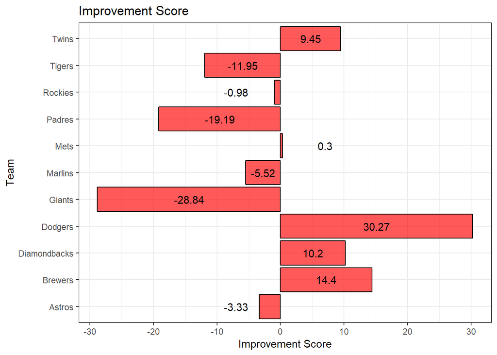

```r
 mostImproved <- rbind(
   CalculateImprovement(giants),
   CalculateImprovement(db),
   CalculateImprovement(dodgers),
   CalculateImprovement(padres),
   CalculateImprovement(rockies),
   CalculateImprovement(astros),
   CalculateImprovement(brewers),
   CalculateImprovement(marlins),
   CalculateImprovement(mets),
   CalculateImprovement(tigers),
   CalculateImprovement(twins)
 )

# mostImproved

 ggplot(mostImproved) +
   geom_bar(aes(x=Team, weight=Improvement), fill="red", color="black", alpha=0.65) +
   geom_text(aes(x=Team, y=Position, label = Improvement)) +
   coord_flip() +
   theme_bw() +
   labs(title="Improvement Score", y="Improvement Score")
```

The improvement score is a weighted sum of the (normalized by number of games per season) difference between wins, runs, runs scored, doubles, tripples, homeruns, and errors committed for the 2018 season and the 1998 season. The most improved score goes to The Dodgers. Their improvement score is 30.

**New Tools:**

- Functions
- Conditionals
- Better visualization
- More data wrangling

## Bing

The Home run Award: which team over time has been the best home run hitting team?

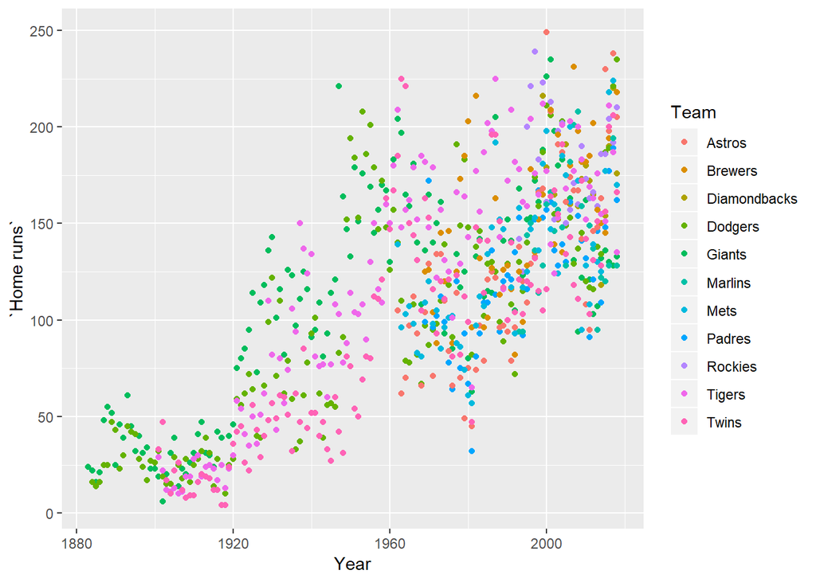

```r
library(lubridate)

# data

modernData <- data %>% filter(League == "AL Central" | League == "AL West" | League == "AL East" |League == "NL Central" | League == "NL West" | League == "NL East")


ggplot(data = data) + geom_point(mapping = aes(x = Year, y = `Home runs`, color = Team))
```

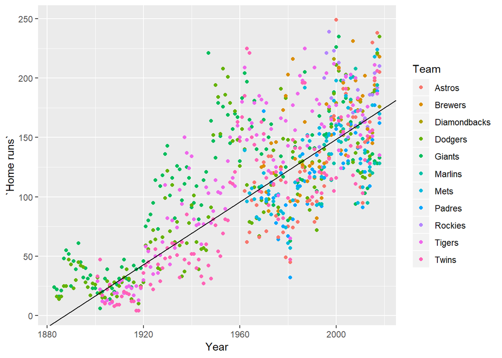

```r
model = lm(`Home runs` ~ Year , data = modernData)


ggplot(data = data) + geom_point(mapping = aes(x = Year, y = `Home runs`, color = Team)) + geom_abline(intercept = -2493.37, slope = 1.321)
```

This is the plot of the all the teams and their homeruns over time. the black line is the regression line for all teams homeruns per year.

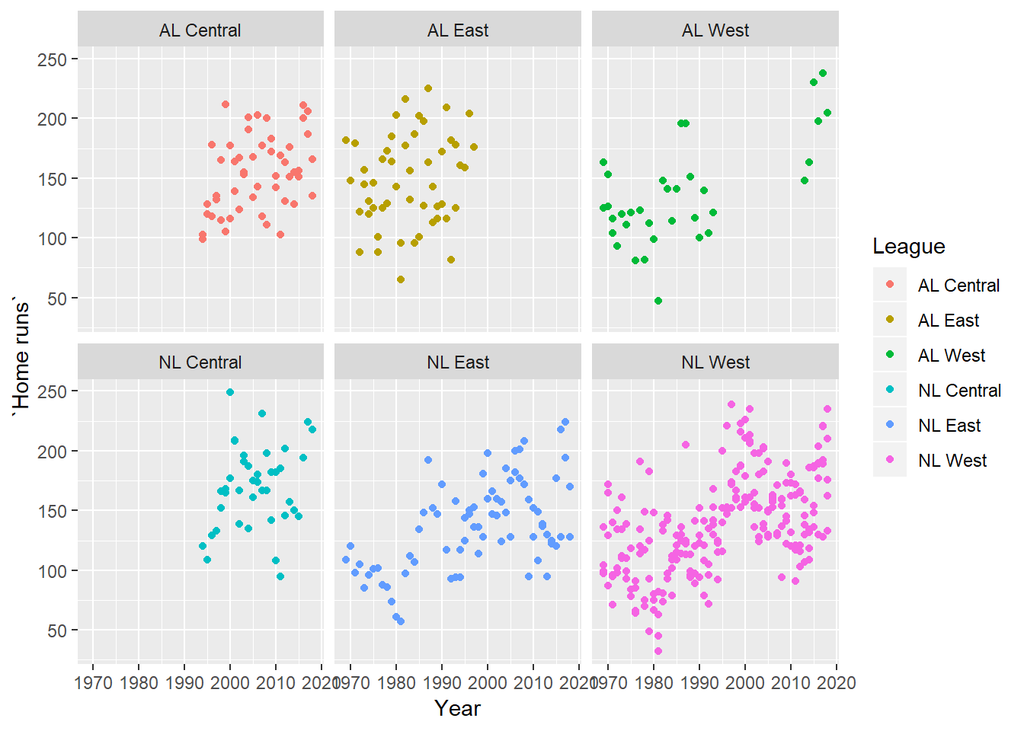

```r
ggplot(data = modernData) + geom_point(mapping = aes(x = Year, y = `Home runs`, color = League)) + facet_wrap(~ League, nrow = 2)
```

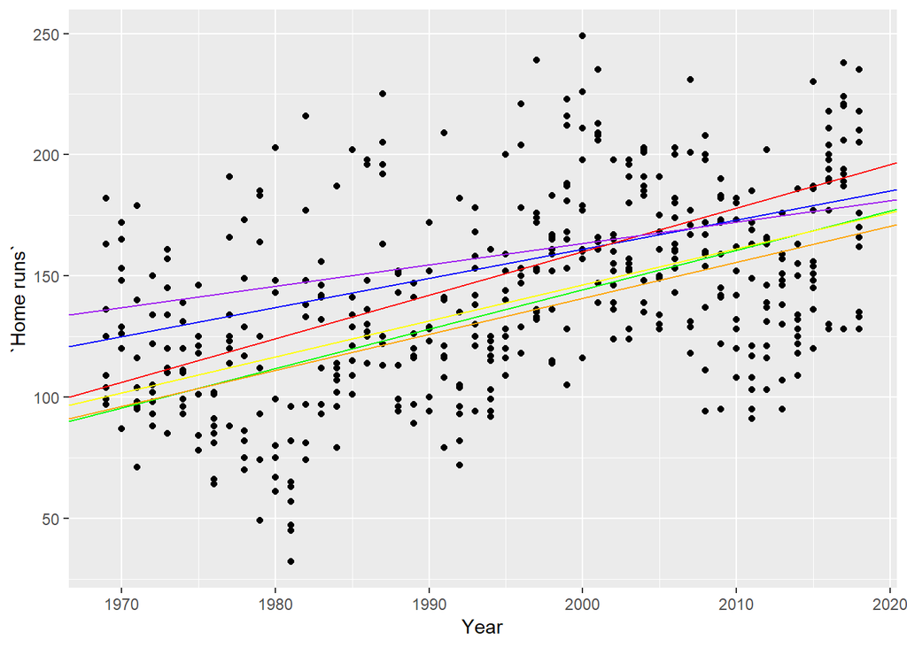

```r
AC <- modernData %>% filter(League == "AL Central")
AW <- modernData %>% filter(League == "AL West")
AE <- modernData %>% filter(League == "AL East")
NC <- modernData %>% filter(League == "NL Central")
NE <- modernData %>% filter(League == "NL East")
NW <- modernData %>% filter(League == "NL West")

modelAC = lm(`Home runs` ~ Year , data = AC)
modelAW = lm(`Home runs` ~ Year , data = AW)
modelAE = lm(`Home runs` ~ Year , data = AE)
modelNC = lm(`Home runs` ~ Year , data = NC)
modelNE = lm(`Home runs` ~ Year , data = NE)
modelNW = lm(`Home runs` ~ Year , data = NW)


ggplot(data = modernData) + geom_point(mapping = aes(x = Year, y = `Home runs`)) + geom_abline(intercept = -2238.9, slope = 1.2, color = "blue") + geom_abline(intercept = -3425.979, slope = 1.793, color = "red") + geom_abline(intercept = -3103.675, slope = 1.624, color = "green") +
geom_abline(intercept = -1599.6820, slope = 0.8815, color = "purple") +
geom_abline(intercept = -2827.194, slope = 1.484, color = "orange") +
geom_abline(intercept = -2825.563 , slope = 1.486, color = "yellow")
```

Line Colors: green - AL Central red - AL West purple - AL East blue - NL Central yellow - NL West orange - NL East

As we can see from these plots that AL West has the largest slope and ends with the highest amount of homeruns in 2018. We will look at the teams in the AL West to see who is our best team.

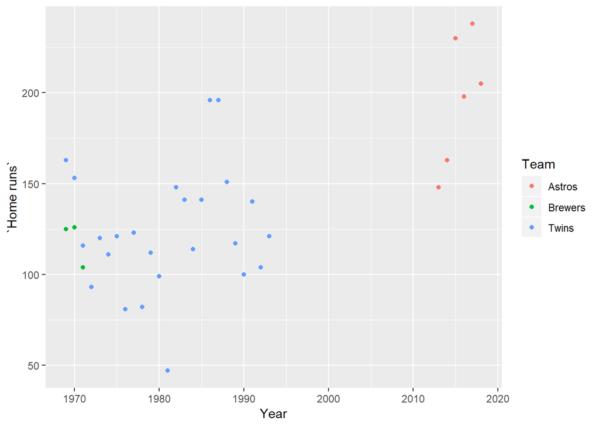

```r
LeagueHR <- modernData %>% filter(League == "AL West")

ggplot(data = LeagueHR) + geom_point(mapping = aes(x = Year, y = `Home runs`,color = Team))
```

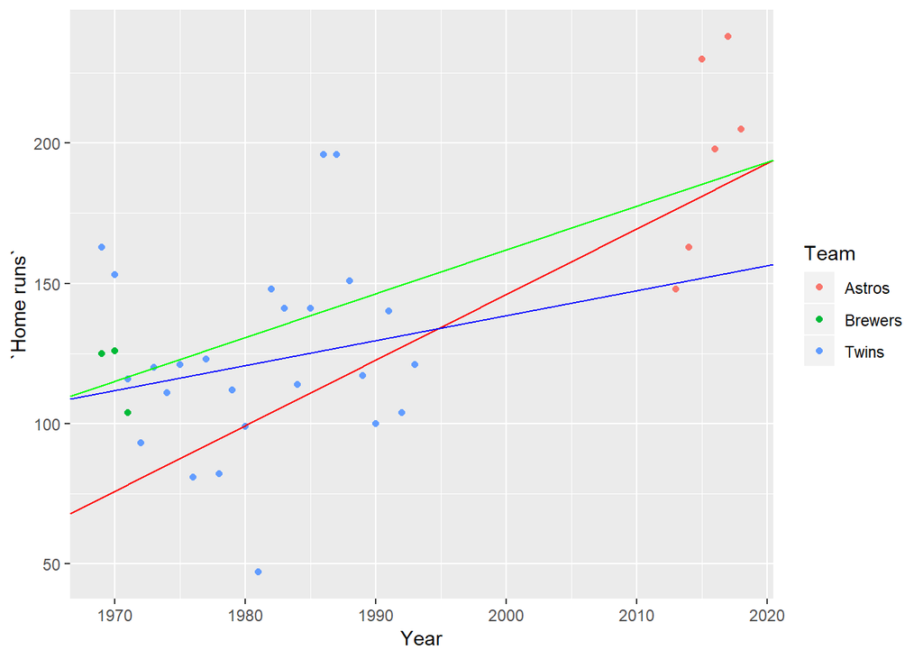

```r
Astros <- modernData %>% filter(Team == "Astros")
Brewers <- modernData %>% filter(Team == "Brewers")
Twins <- modernData %>% filter(Team == "Twins")

modelStros = lm(`Home runs` ~ Year , data = Astros)
modelBrewers = lm(`Home runs` ~ Year , data = Brewers)
modelTwins = lm(`Home runs` ~ Year , data = Twins)

#modelStros
#modelBrewers
#modelTwins

ggplot(data = LeagueHR) + geom_point(mapping = aes(x = Year, y = `Home runs`,color = Team)) + geom_abline(intercept = -4531.771, slope = 2.339, color = "red") + geom_abline(intercept = -2961.989, slope = 1.562 , color = "green") + geom_abline(intercept = -1638.6750, slope = 0.8886 , color = "blue")
```

As we can see the Astros have the highest slope and ends in 2018 with the most out of the AL West teams so they are crowned our Home Run championship. This is important because Home Runs are one of the most important parts of Baseball both statistically and for the fans, so to determine the best team Home runs should definitely be included. The new tools that I used were models and multiple models. This shows that Astros can bring fans and also do statistically well.

## Brandon

Most Offensive team

```r
#calcLocation <- function(offense){
     #if(abs(offense)<5) {
      # return(sign(offense)*7)
     #}else{
         #return(offense/2)
       #}
  #}

#CalculateOffense <- function(db){
  #Name <- db$Team[1]
  #db <- db %>% filter(Year==2018 | Year==1998)
  #RunsPerGame <- (df$`Runs per Game`[1]/df$`Number of Games`[1]) - (df$`Runs per Game`[2]/df$`Number of Games`[2])
  #RunsScored <- (df$`Runs scored`[1]/df$`Number of Games`[1]) - (df$`Runs scored`[2]/df$`Number of Games`[2])
  #RBIs <- (df$RBIs[1]/df$`Number of Games`[1]) - (df$RBIs[2]/df$`Number of Games`[2])
  #OnBase <-(df$`On base %`[1]/df$`Number of Games`[1]) - (df$`On base %`[2]/df$`Number of Games`[2])
  #BattingAvg <- (df$`Batting average`[1]/df$`Number of Games`[1]) - (df$`Batting average`[2]/df$`Number of Games`[2])
  #Slugging <- (df$`Slugging %`[1]/df$`Number of Games`[1]) - (df$`Slugging %`[2]/df$`Number of Games`[2])
#best <- c(RunsPerGame, RunsScored, RBIs, onBase, BattingAvg, Slugging)
  #weights <- c(20, 10, 15, 10, 15, 20, 10)

  #offense <- best %*% weights %>% round(2)
  #Location <- calcLocation(offense)


  #bb <- tribble(~Team, ~offense, ~Location,
   #            Name, offense, Location)
  #return(bb)
#}
```

```r
 #mostImproved <- rbind( CalculateOffense(giants),CalculateOffense(db),CalculateOffense(dodgers),CalculateOffense(padres),CalculateOffense(rockies),CalculateOffense(astros),CalculateOffense(brewers), CalculateOffense(marlins), CalculateOffense(mets), CalculateOffense(tigers), CalculateOffense(twins))
 #ggplot(mostImproved) +
  # geom_bar(aes(x=Team, weight=Improvement), fill="red", color="black", alpha=0.65) +
   #geom_text(aes(x=Team, y=Position, label = Improvement)) +
   #coord_flip() +
   #theme_bw() +
   #labs(title="Improvement Score", y="Improvement Score")
```

COuldn’t get the plot to work, but based off the gather data and indivdual runs it looked like the Dodgers and the msot offense team from 1989 to 2018, this can due to their increase in wins which is cotnributed to score, RBI’s stolen bases and othe rthing I tested for offense teams

# Reflections:

## Team

We have achieved our team goals. We are all fluent in R markdown and have learned new data science tools. These are skills that we can use for the rest of our lives. They will be very helpful. We did well on all of our tRATs, so we wouldn’t change that. One thing we could have done better is starting the labs earlier. We were always finishing tem minutes before the deadline.

### Matt

Six months after graduation, I said that I wanted to be traveling around the world. This is still my goal. I think that I am still likely to acheive it. My 5 year plan has changed a little. Before, I wanted to be a data scientist, but now I know that I want to do research that allows me to study the earth and travel. I learned a lot of cool data visualization tools in this class. I became fluent in RStudio (especially r markdown). We explored some really cool datasets. If I could give myself advice at the begining of the year, I would tell myself to make sure to read all of the readings. I read all of the readings on time and it really helped my understanding of the material.

## Bing

I said that I want to be able to find insights about Basketball by analyzing data, and while this is still a goal of mine, I have not achieved it yet, however I would say that since the beginning of the semester, I can anaylyze data much better, and as we showed in this project we analyzed Baseball and made more minor insights. 6 months after graduation I would still like to be travelling, but 5 years after graduation, I still would like to data analytics, but I would be open to many fields. I would say for my goals for the semester, I acheived those because those were mostly about improving my basic R skills. I would tell myself to just make sure to know the stuff from the reading because I had 2 tests where I didn’t try to hard and din’t get great grades on.

## Brandon

I said that I want to do statistics on videoGames and profesional videoGame players. My goal has changed a little bit from then I want to do something economcialy related or in the business deartment becuase I think it’s interesting how money works. ALso the fact my Dad is a banker was an influence. During the cours eof this year I have learned alot that I never thought i would I have and it has been an amazing year to learn R studio and exploring intersting data

# Who did what:

#### Matt

- Helped with overall question choice
- Setup the markdown file
- Chose a subquestion
- Created data frames, functions, and plots to answer the subquestion
- Downloaded files from [baseball-reference.com](https://www.baseball-reference.com/teams/)
- Read in the files into useable, tidy data frames for later use
- Reflected on lab 2 and this course

#### Brandon

helped with overall question - reflection on the lab -indivdual part

#### Bing

-Helped with overall question -chose a subquestion -download file from our source -reflected on lab 2 -did indivdual part -did team reflection